# Getting started with the pseudo-bulk simulator R package

Alexander Dietrich

# Installation

To install the package, run this: (Since it is a private repository, you currently need an authentification token for this repository.)

```r
install.packages("devtools")
devtools::install_github("omnideconv/simulator") #add auth=XXX to download from private repository
```

```r
library(simulator)
library(data.table)
library(tidyr)
library(Matrix)
library(Seurat)
```

```r
library(ggplot2)
library(RColorBrewer)
```

# Introduction

Cell-type deconvolution is an important analysis-step while processing bulk RNA-seq experiments and many tools exist to tackle this issue. Though the user lacks a good comparison between those tools and when one might be more beneficial than others.  
The goal of this simulator is to create benchmark datasets, where pseudo bulk sample with predefined cell-type fractions can be simulated using expression data from single-cell RNAseq experiments.

# Getting started

This chapter covers all you need to know to quickly simulate some pseudo-bulk samples!

## Setup the simulator

This package can simulate samples from local or public data. We will start with the public data integration, since it requires mostly no manual download of datasets. As a public database, sfaira (Fischer et al. 2020) is used, which is a dataset and model repository for single-cell RNA-sequencing data. It gives access to about 233 datasets from human and mouse with more than 3 million cells in total. You can browse them interactively here: https://theislab.github.io/sfaira-portal/Datasets. Note that only annotated datasets will be downloaded!  
In order to use this database, we first need to install it using conda. Simply follow [this installation tutorial](https://sfaira.readthedocs.io/en/latest/installation.html). You do not need to activate the new conda environment in order to use it later on.  
To setup sfaira inside of the R package use this command:

```r
setup_list <- simulator::setup_sfaira(python_path = "/nfs/home/students/adietrich/.conda/envs/sfaira/bin/python3",
                                      env_name = "sfaira",
                                      basedir = "/nfs/home/students/adietrich/ma/data/sfaira")
```

The `python_path` parameter is used to set the path to the python executable **inside** of the newly created conda environment. Similarly, the `env_name` parameter is the name of this newly created conda environment. These two parameters need to be set correctly, so that sfaira can be used later on.  
The third parameter describes the name of a directory in which the raw files, meta data and cached data from downloading datasets from sfaira are stored into.  
You need to save the output of the command above in a variable for later use.  
If you do not wish to use sfaira, just skip this step entirely.

## Creating a dataset

The simulator package works with two internally defined data-structures: *datasets* and *databases*.  
We will now create a dataset of samples from human pancreas using the `organisms` and `tissues` parameter. You can provide a single word (like we do here) or for example a list of tissues you want to download: `c("pancreas","lung")`. An additional parameter is the `assays` parameter, where you subset the database further to only download datasets from certain sequencing assays (for examples `Smart-seq2`).  
The `name` parameter is used later on to give each sample a unique name.

```r
ds_human_pancreas <- simulator::dataset_sfaira_multiple(sfaira_setup = setup_list,
                                                        organisms = "human",
                                                        tissues = "pancreas",
                                                        name="human_pancreas")
```

```
#> [1] "Removing datasets without cell-type annotation..."
#> [1] "Downloading datasets..."
#> [1] "Streamlining features & meta-data..."
#> [1] "Using rownames for cell-IDs."
```

Currently there are two datasets in sfaira from human pancreas, which have cell-type annotation. The package will download them for you automatically and merge them together into a single expression matrix and a streamlined annotation table, which we can use for our simulation.  
It can happen, that some datasets from sfaira are not (yet) ready for the automatic download, an error message will then appear in R, telling you which file to download and where to put it.

## Simulate pseudo bulk datasets

We are now ready to simulate the first pseudo bulk samples with the created dataset:

```r
simulation <- simulator::simulate_bulk(data = ds_human_pancreas,
                                       scenario = "random",
                                       scaling_factor = "none",
                                       ncells=1000,
                                       nsamples = 50,
                                       ncores = 12)
```

`ncells` sets the number of cells in each sample, while `nsamples` sets the total amount of simulated samples.  
You can also control the number of cells per sample by using the `total_read_counts` parameter, which sets the total number of counts per sample. This can be used to simulate different sequencing depths. If you wish to use this parameter, it is important to know what type of expression data you have (raw or normalized). If you for example use TPMs as expression values and set the total read counts to `1e7`, this will get you really huge samples with many cells, since TPM values are generally smaller than the raw count values.

Currently there are 4 `scenarios` implemented in the package:

- *random*: for each cell in a sample, the cell-type is chosen randomly. This scenario is depending on the background distribution of the cell-types in the created dataset. If for example your dataset contains 20% B-cells, 40% T-cells and 40% Macrophages, this scenario will create samples where this distribution is mirrored closely.
- *uniform*: this creates samples, where all existing cell-types in the dataset appear in the same proportions. So using a dataset with 3 cell-types, this will simulate samples, where all cell-type fractions are 1/3.
- *spike-in*: here you need to set two additional parameters for the `simulate_bulk()` function: `spike_in_cell_type` sets the cell-type you want to be over-representing and `spike_in_amount` sets the fraction of this cell-type. You could for example use `B-cell` and `0.5` to create samples, where 50% are B-cells and the rest is filled randomly with other cell-types.
- *spill-over*: this simulates samples with only a single cell-type present. Like with *spike-in* you need to set this cell-type with the additional parameter `spillover_cell_type`.

## Results

The `simulation` object contains three named entries:

- `pseudo_bulk`: a sparse matrix with - in this case - 50 columns and about 60k rows (this is the number of features/genes). This is the simulated expression matrix.
- `cell_fractions`: a dataframe with 50 rows and 15 columns (this is the number of cell-types). It gives the fractions for each cell-type in each sample.
- `expression_set`: a Biobase [ExpressionSet](https://rdrr.io/bioc/Biobase/man/class.ExpressionSet.html)

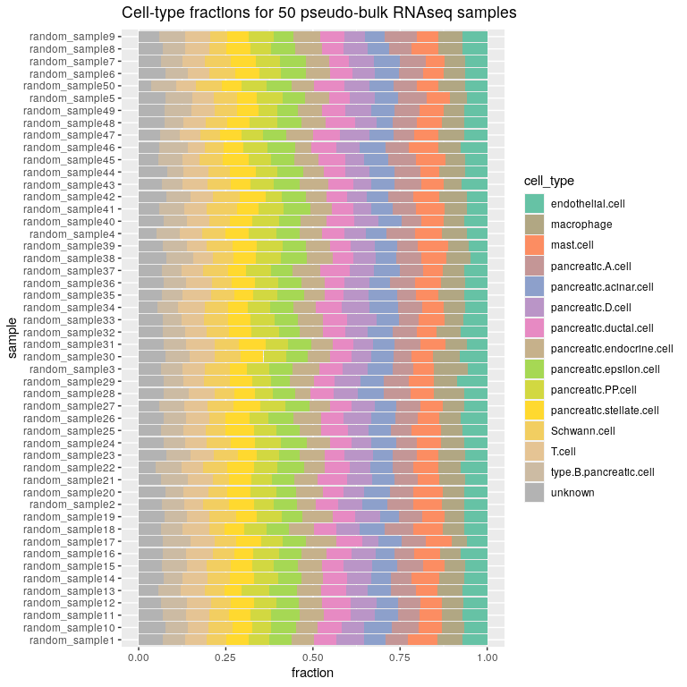

```r
fractions <- simulation$cell_fractions
fractions$sample <- rownames(fractions)
frac_long <- gather(fractions, cell_type, fraction, 1:length(fractions)-1)

ggplot(frac_long, aes(x=fraction, y=sample, fill=cell_type))+
  geom_col()+
  ggtitle("Cell-type fractions for 50 pseudo-bulk RNAseq samples")+
  scale_fill_manual(values = colorRampPalette(brewer.pal(8, "Set2"))(length(unique(frac_long$cell_type))))
```

# More features

## Using your own data

The simulator also has the option to create datasets with your own scRNAseq experiments. You can create datasets in three different ways:

- Using a expression matrix & annotation file

```r
# change paths accordingly
counts <- Matrix(as.matrix(fread("~/ma/data/Maynard/X_tpm.csv")), sparse = T)
genes <- fread("~/ma/data/Maynard/var.csv")
cells <- fread("~/ma/data/Maynard/obs.csv")
cellnames <- cells$Run
genenames <- genes$symbol
dimnames(counts)<-list(cellnames, genenames)
counts <- t(counts)

annotation <- fread("~/ma/data/Maynard/annotation_obs.csv")[,c("Run","cell_type")]
colnames(annotation) <- c("ID", "cell_type")

dataset_file <- simulator::dataset(annotation = annotation,
                                   count_matrix = counts,
                                   name="Maynard")
```

- Using a h5ad expression data & annotation file

```r
# change paths accordingly
counts <- "~/ma/data/Travaglini/Travaglini_Krasnow_2020_Lung_SS2.h5ad"
annotation <- fread("~/ma/data/Travaglini/obs_extended.csv")
# renaming the columns
colnames(annotation)[which(colnames(annotation) == "free_annotation")]<-"cell_type"
colnames(annotation)[which(colnames(annotation) == "index")]<-"ID"

dataset_h5ad <- simulator::dataset_h5ad(annotation = annotation,
                                        h5ad_file = counts,
                                        name = "Travaglini")
```

- Using a Seurat Object and annotation file

```r
# download Seurat object from tabula muris
# https://figshare.com/ndownloader/files/13088531
load("~/ma/data/tabula_muris/tabula_muris_bladder.Robj")
seurat_obj <- Seurat::UpdateSeuratObject(tiss)
```

```
#> Updating from v2.X to v3.X
#> Validating object structure
#> Updating object slots
#> Ensuring keys are in the proper strucutre
#> Ensuring feature names don't have underscores or pipes
#> Object representation is consistent with the most current Seurat version
```

```r
annotation <- seurat_obj@meta.data
# renaming the columns
colnames(annotation)[which(colnames(annotation) == "free_annotation")]<-"cell_type"
annotation$ID <- rownames(annotation)

dataset_seurat <- simulator::dataset_seurat(annotation = annotation,
                                            seurat_obj = seurat_obj,
                                            name="TabulaMuris_Bladder")
```

**Important:** the annotation dataframe you are feeding into the dataset, needs these two columns: `ID` for the cell ID, which has to be in common with the cell IDs in the expression matrix and `cell_type`, which gives the cell-type for a cell.

## Simulate using a whitelist of cell-types

Sometimes, you are only interested in specific cell-types, but the dataset you are using has way too many cell-types:

```r
unique(dataset_file@annotation$cell_type)
```

```
#>  [1] "Monocyte conventional"      "Macrophage"
#>  [3] "Endothelial cell"           "Mast cell"
#>  [5] "B cell"                     "T cell CD8"
#>  [7] "T cell CD4"                 "Alevolar cell type 2"
#>  [9] "Basal"                      "Smooth muscle cell"
#> [11] "NK cell"                    "other C17"
#> [13] "Monocyte non-conventional"  "cDC2"
#> [15] "Epithelial cell other C5"   "Fibroblast adventitial"
#> [17] "Club"                       "Epithelial cell other C4"
#> [19] "DC mature"                  "Epithelial cell other C1"
#> [21] "Plasma cell"                "Epithelial cell other C3"
#> [23] "Pericyte"                   "Alevolar cell type 1"
#> [25] "T cell regulatory"          "pDC"
#> [27] "Epithelial cell other C2"   "Ciliated"
#> [29] "other C21"                  "other C19"
#> [31] "Fibroblast alevolar"        "cDC1"
#> [33] "Mesothelial"                "Endothelial cell lymphatic"
#> [35] "DC Lagerhans"               "Epithelial cell dividing"
#> [37] "T cell dividing"            "other C29"
#> [39] "Ionocyte"                   "other C32"
#> [41] "other C33"                  "Goblet"
```

```r
length(unique(dataset_file@annotation$cell_type))
```

```
#> [1] 42
```

You can handle this issue during simulation using the `whitelist` parameter:

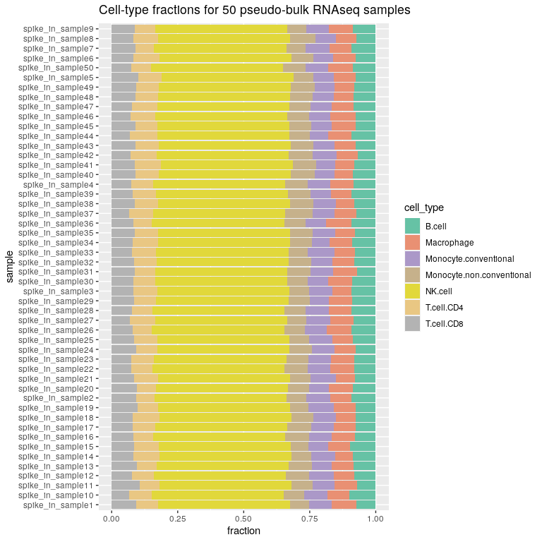

```r
simulation <-  simulator::simulate_bulk(data = dataset_file,
                                        scenario = "spike-in",
                                        scaling_factor = "none",
                                        spike_in_cell_type = "NK cell",
                                        spike_in_amount = 0.5,
                                        ncells=1000,
                                        nsamples = 50,
                                        ncores = 12,
                                        whitelist = c("NK cell","B cell","T cell CD8", "T cell CD4", "Macrophage", "Monocyte conventional", "Monocyte non-conventional"))

fractions <- simulation$cell_fractions
fractions$sample <- rownames(fractions)
frac_long <- gather(fractions, cell_type, fraction, 1:length(fractions)-1)

ggplot(frac_long, aes(x=fraction, y=sample, fill=cell_type))+
  geom_col()+
  ggtitle("Cell-type fractions for 50 pseudo-bulk RNAseq samples")+
  scale_fill_manual(values = colorRampPalette(brewer.pal(8, "Set2"))(length(unique(frac_long$cell_type))))
```

## Using scaling factors (Census)

[I am still working on this section..]

[Census](http://cole-trapnell-lab.github.io/monocle-release/docs/#census) is an approach which tries to convert TPM counts into relative transcript counts. This basically means, you get the mRNA counts per cell, which can differ between cell-types.  
(Qiu et al. 2017) state in their paper, that it should only be applied to TPM/FPKM normalized data, but I tried it out with raw expression counts as well, which worked as well.  
Census calculates a vector with a scaling value for each cell in a sample. The simulated expression matrix will be multiplied with this vector in order to census-normalize the pseudo-bulk sample.  
You can switch this feature on, by setting the `scaling_factor` parameter to `census`.

```r
simulation <-  simulator::simulate_bulk(data = dataset_file,
                                        scenario = "spike-in",
                                        scaling_factor = "census",   # use census scaling factor
                                        spike_in_cell_type = "NK cell",
                                        spike_in_amount = 0.5,
                                        ncells=1000,
                                        nsamples = 50,
                                        ncores = 12,
                                        whitelist = c("NK cell","B cell","T cell CD8", "T cell CD4", "Macrophage", "Monocyte conventional", "Monocyte non-conventional"))
```

# References

Fischer, David S., Leander Dony, Martin König, Abdul Moeed, Luke Zappia, Sophie Tritschler, Olle Holmberg, Hananeh Aliee, and Fabian J. Theis. 2020. “Sfaira Accelerates Data and Model Reuse in Single Cell Genomics.” *bioRxiv*. https://doi.org/10.1101/2020.12.16.419036.

Qiu, Xiaojie, Andrew Hill, Jonathan Packer, Dejun Lin, Yi-An Ma, and Cole Trapnell. 2017. “Single-Cell mRNA Quantification and Differential Analysis with Census.” *Nature Methods* 14 (3): 309–15. https://doi.org/10.1038/nmeth.4150.